# Analysis of Global Delivery Quality

As we saw from the EDA, the delivery quality was a signifant factor that determined the happiness score. I thought this was an interesting finding and wanted to analyze if this factor is related to the geographical factor.

```r
# Load libraries
library(tidyverse)
library(sf)
library(spdep)
library(viridis)
library(readxl)
library(rnaturalearth)
library(rnaturalearthdata)
library(corrplot)
```

```r
# Load spatial and happiness datasets
world_sf <- rnaturalearth::ne_countries(scale = "medium", returnclass = "sf")
happiness_data <- read_excel("../data/WHR20_DataForTable2.1.xls")
```

```r
# Select relevant columns
happiness_data <- happiness_data %>%
  select(
    `year`, `Country name`, `Life Ladder`, `Log GDP per capita`, `Delivery Quality`
  )
```

```r
# Ensure the Life Ladder column is numeric
happiness_data <- happiness_data %>%
  mutate(`Life Ladder` = as.numeric(`Life Ladder`))
```

```r
# Merge spatial and happiness data
merged_sf <- left_join(world_sf, happiness_data, by = c("name" = "Country name"))
merged_sf <- merged_sf[!is.na(merged_sf$`Life Ladder`), ] # Remove rows with missing happiness scores
```

```r
merged_sf <- st_transform(merged_sf, crs = 3857)
```

```r
summary(merged_sf$`Delivery Quality`)
```

```
    Min.  1st Qu.   Median     Mean  3rd Qu.     Max.     NA's
-2.14497 -0.71260 -0.20727 -0.00128  0.67290  2.18472      127
```

The analysis began by integrating the Delivery Quality variable from the World Happiness Report with global spatial data. After filtering out rows with missing values, the dataset covered countries with valid Delivery Quality scores, ranging from -2.14 (low) to 2.18 (high). The mean score was close to zero, indicating a balanced distribution around the global average. This variable highlights significant disparities between countries, reflecting differences in governance and institutional efficiency.

### Spatial Autocorrelation

```r
# Filter out rows with missing values
merged_sf_clean <- merged_sf[!is.na(merged_sf$`Delivery Quality`), ]

# Compute Moran's I for Delivery Quality
delivery_quality_nb <- spdep::poly2nb(merged_sf_clean, queen = TRUE)

# Allow empty neighbor sets
delivery_quality_listw <- spdep::nb2listw(delivery_quality_nb, style = "W", zero.policy = TRUE)

# Compute Moran's I for the numeric version of Delivery Quality
delivery_quality_moran <- spdep::moran.test(merged_sf_clean$`Delivery Quality`, delivery_quality_listw, zero.policy = TRUE)

# Print the Moran's I result
print(delivery_quality_moran)
```

```
    Moran I test under randomisation

data:  merged_sf_clean$`Delivery Quality`
weights: delivery_quality_listw
n reduced by no-neighbour observations

Moran I statistic standard deviate = 117.76, p-value < 2.2e-16
alternative hypothesis: greater
sample estimates:
Moran I statistic       Expectation          Variance
     0.7382296175     -0.0006369427      0.0000393707
```

The Moran’s I test was applied to evaluate the spatial autocorrelation of Delivery Quality. The result (Moran’s I = 0.738, p-value < 2.2e-16) indicates a strong and statistically significant clustering of delivery quality scores. This means that countries with similar scores—whether high or low—are geographically proximate, suggesting that regional factors such as shared economic conditions or governance practices play a role in delivery quality.

### Exploratory Visualizations

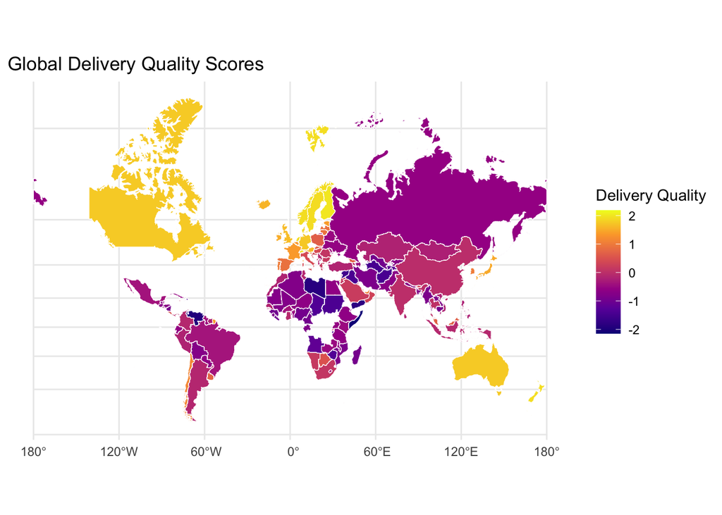

```r
ggplot(merged_sf_clean) +
  geom_sf(aes(fill = `Delivery Quality`), color = "white") +
  scale_fill_viridis_c(option = "C", na.value = "gray") +
  theme_minimal() +
  labs(title = "Global Delivery Quality Scores", fill = "Delivery Quality")
```

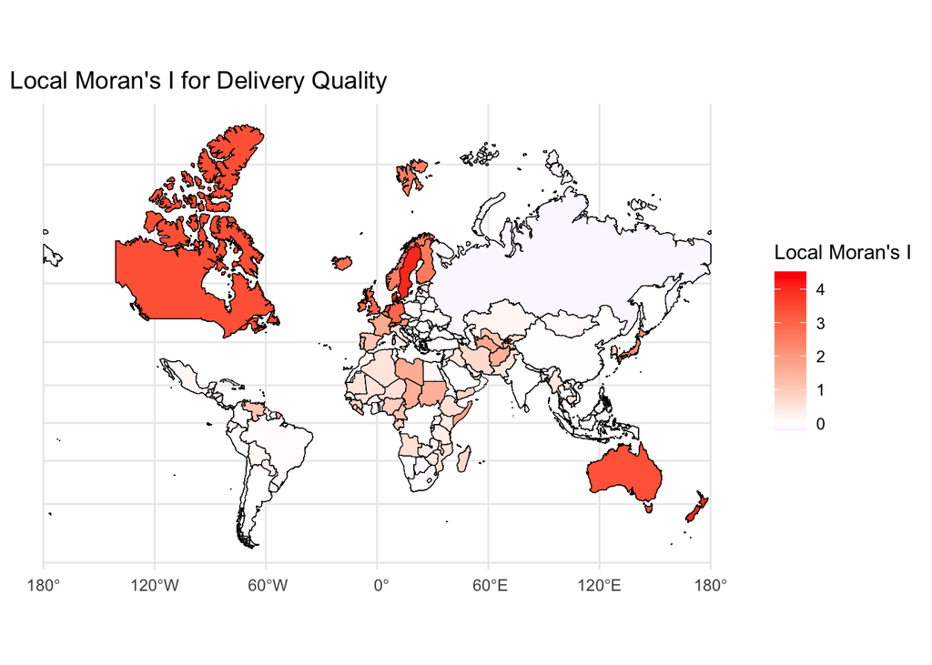

```r
local_moran <- spdep::localmoran(merged_sf_clean$`Delivery Quality`, delivery_quality_listw)
merged_sf_clean$Ii <- local_moran[, "Ii"]
merged_sf_clean$p_value <- local_moran[, "Pr(z != E(Ii))"]

ggplot(merged_sf_clean) +
  geom_sf(aes(fill = Ii), color = "black") +
  scale_fill_gradient2(low = "blue", mid = "white", high = "red", midpoint = 0) +
  theme_minimal() +
  labs(title = "Local Moran's I for Delivery Quality", fill = "Local Moran's I")
```